# Week III

STAT 420, Summer 2018, Scott Bishop

June 2018

# Exercise 1 (Using `lm` for Inference)

For this exercise we will use the `cats` dataset from the `MASS` package. You should use `?cats` to learn about the background of this dataset.

```r
library(MASS)
head(cats)
```

```
##   Sex Bwt Hwt
## 1   F 2.0 7.0
## 2   F 2.0 7.4
## 3   F 2.0 9.5
## 4   F 2.1 7.2
## 5   F 2.1 7.3
## 6   F 2.1 7.6
```

### A

Fit the following simple linear regression model in `R`. Use heart weight as the response and body weight as the predictor.

$$Y_i = \beta_0 + \beta_1 x_i + \epsilon_i$$

```r
cat.model <- lm( Hwt ~ Bwt, data = cats )
beta.0    <- summary( cat.model )$coefficients[1]
beta.1    <- summary( cat.model )$coefficients[2]
y.i       <- beta.0 + ( beta.1 * cats$Bwt )
```

Store the results in a variable called `cat_model`. Use a $t$ test to test the significance of the regression. Report the following:

- The null and alternative hypotheses  
  $H_0: \beta = 0$  
  $H_1: \beta \neq 0$  
  $\alpha = 0.05$
- The value of the test statistic

```r
test.stat <- summary( cat.model )$coefficients[ "Bwt", "t value" ]
test.stat
```

```
## [1] 16.11939
```

- The p-value of the test

```r
p.value <- summary(cat.model)$coefficients[ 2, "Pr(>|t|)" ]
p.value
```

```
## [1] 6.969045e-34
```

- A statistical decision at $\alpha = 0.05$

```r
p.value < 0.05
```

```
## [1] TRUE
```

Reject the null hypothesis $H_0$ in favor of the alternative $H_1$.  
the p-value of $6.969045e-34$ is smaller than the $\alpha$ of $0.05$.

- A conclusion in the context of the problem

The predictor “Bwt” has a low p-value of $6.969045e-34$, which means that the cat’s body weight is likely to be a meaningful addition to the “cat.model” because changes in the predictor’s value are related to changes in the response variable: the cat’s heart weight.

### B

Calculate a 90% confidence interval for $\beta_1$. Give an interpretation of the interval in the context of the problem.

```r
confint( object = cat.model, parm = "Bwt", level = .90 )
```

```
##          5 %     95 %
## Bwt 3.619716 4.448409
```

We are 90% confident that true change in the parameter “Hwt” for change in “Bwt” is between 3.619716 and 4.4484094

### C

Calculate a 99% confidence interval for $\beta_0$. Give an interpretation of the interval in the context of the problem.

```r
confint( object = cat.model, param = "(Intercept)", level = .99 )
```

```
##                 0.5 %   99.5 %
## (Intercept) -2.164125 1.450800
## Bwt          3.380656 4.687469
```

### D

Use a 99% confidence interval to estimate the mean heart weight for body weights of 2.1 and 2.8 kilograms. Which of the two intervals is wider? Why?

```r
new.cat <- data.frame( Bwt = c( 2.1, 2.8 ) )

prediction <- predict( cat.model, newdata = new.cat,
                       interval = c( "confidence" ), level = .99 )

interval.1 <- prediction[ 1, "upr" ] - prediction[ 1, "lwr" ]
interval.2 <- prediction[ 2, "upr" ] - prediction[ 2, "lwr" ]

interval.1
```

```
## [1] 1.031288
```

```r
interval.2
```

```
## [1] 0.6398344
```

```r
mean(cats$Bwt)
```

```
## [1] 2.723611
```

The mean of the predictor value “Bwt” is $2.723611$, so at the prediction of 2.8 the confidence interval will be narrower. Therefore at the prediction of 2.1, which is further from the mean predictor value, the confidence interval will be wider.

### E

Use a 99% prediction interval to predict the heart weight for body weights of 2.8 and 4.2 kilograms.

```r
new.cat <- data.frame( Bwt = c( 2.8, 4.2 ) )

prediction <- predict( cat.model, newdata = new.cat,
              interval = c( "prediction" ), level = .99 )

prediction[ , "fit" ]
```

```
##        1        2
## 10.93871 16.58640
```

```r
min( cats$Bwt ) < 4.2 && 4.2 < max( cats$Bwt )
```

```
## [1] FALSE
```

NOTE: Since the value of 4.2 kilograms is not in the interval of the seen data, the estimate will be prone to extrapolation and therefore be less reliable.

### F

Create a scatterplot of the data. Add the regression line, 90% confidence bands, and 90% prediction bands.

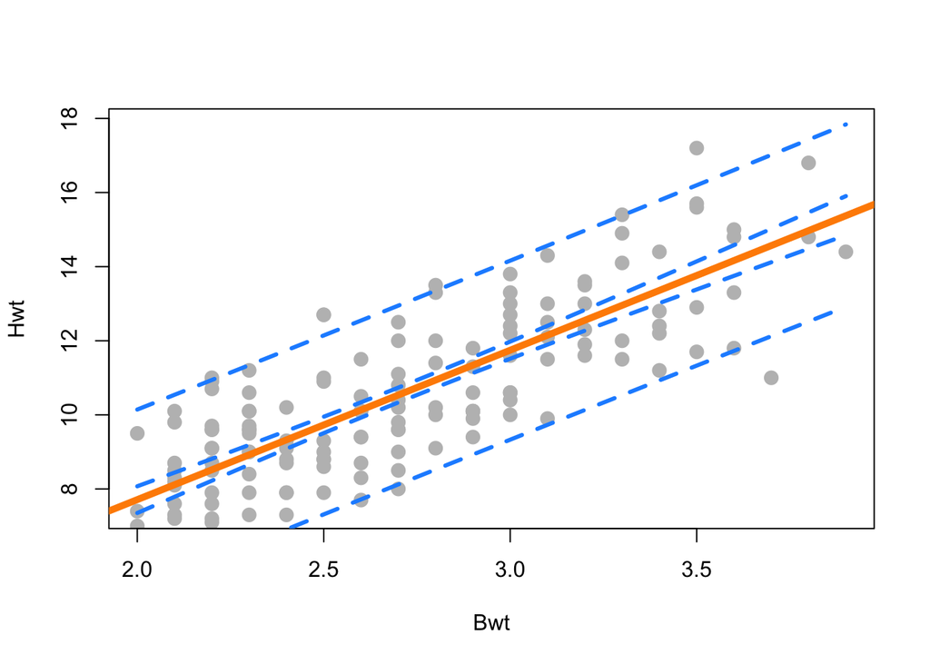

```r
cat.grid <- seq( min( cats$Bwt ), max( cats$Bwt ), by = 0.01 )

cat.ci.band <- predict( cat.model, newdata = data.frame( Bwt = cat.grid ),
                        interval = c( "confidence" ), level = .90 )

cat.pi.band <- predict( cat.model, newdata = data.frame( Bwt = cat.grid ),
                        interval = c( "prediction" ), level = .90 )

plot( Hwt ~ Bwt, data = cats,
      pch = 20, cex = 2, col = "grey",
      ylim = c( min( cat.ci.band ), max( cat.pi.band ) ) )
abline( cat.model, lwd = 5, col = "darkorange" )

lines( cat.grid, cat.ci.band[ , "lwr" ], col = "dodgerblue", lwd = 3, lty = 2 )
lines( cat.grid, cat.ci.band[ , "upr" ], col = "dodgerblue", lwd = 3, lty = 2 )
lines( cat.grid, cat.pi.band[ , "lwr" ], col = "dodgerblue", lwd = 3, lty = 2 )
lines( cat.grid, cat.pi.band[ , "upr" ], col = "dodgerblue", lwd = 3, lty = 2 )
```

### G

Use a $t$ test to test:

- $H_0: \beta_1 = 4$
- $H_1: \beta_1 \neq 4$

Report the following:

- The value of the test statistic

```r
se        <- summary( cat.model )$coefficients[ 2, 2 ]
test.stat <- ( beta.1 - 4 ) / se
test.stat
```

```
## [1] 0.1361084
```

- The p-value of the test

```r
pt( test.stat, df = cat.model$df.residual )
```

```
## [1] 0.5540358
```

- A statistical decision at $\alpha = 0.05$

We will NOT reject the null hypothesis $H_0: \beta = 4$ in favor of the alternative hypothesis $H_1: \beta \neq 4$ because the p-value is $0.5540358$, which is larger than the significant value $\alpha$ of $0.05$.

# Exercise 2 (More `lm` for Inference)

```r
library( mlbench )
data( Ozone )
Ozone           <- Ozone[, c(4, 6, 7, 8)]
colnames(Ozone) <- c("ozone", "wind", "humidity", "temp")
Ozone           <- Ozone[complete.cases(Ozone), ]
head( Ozone )
```

```
##   ozone wind humidity temp
## 3     3    4       28   40
## 4     5    3       37   45
## 5     5    3       51   54
## 6     6    4       69   35
## 7     4    6       19   45
## 8     4    3       25   55
```

### A

Fit the following simple linear regression model in `R`. Use the ozone measurement as the response and wind speed as the predictor.

```r
ozone.wind.model <- lm( ozone ~ wind, data = Ozone )
summary( ozone.wind.model )
```

```
##
## Call:
## lm(formula = ozone ~ wind, data = Ozone)
##
## Residuals:
##     Min      1Q  Median      3Q     Max
## -10.730  -6.652  -1.752   4.687  26.359
##
## Coefficients:
##             Estimate Std. Error t value Pr(>|t|)
## (Intercept)  11.8636     1.0856  10.928   <2e-16 ***
## wind         -0.0445     0.2032  -0.219    0.827
## ---
## Signif. codes:  0 '***' 0.001 '**' 0.01 '*' 0.05 '.' 0.1 ' ' 1
##
## Residual standard error: 7.985 on 342 degrees of freedom
## Multiple R-squared:  0.0001402,  Adjusted R-squared:  -0.002783
## F-statistic: 0.04795 on 1 and 342 DF,  p-value: 0.8268
```

Store the results in a variable called `ozone_wind_model`. Use a $t$ test to test the significance of the regression. Report the following:

- The null and alternative hypotheses  
  $H_0: \beta = 0$  
  $H_1: \beta \neq 0$  
  $\alpha = 0.01$
- The value of the test statistic

```r
summary( ozone.wind.model )$coefficients[ "wind", "t value" ]
```

```
## [1] -0.2189811
```

- The p-value of the test

```r
p.value <- summary( ozone.wind.model )$coefficients[ "wind", "Pr(>|t|)" ]
p.value
```

```
## [1] 0.8267954
```

- A statistical decision at $\alpha = 0.01$

```r
p.value < 0.01
```

```
## [1] FALSE
```

- A conclusion in the context of the problem

We fail to reject the null hypothesis $H_0: \beta = 0$ since the p-value of $0.8267954$ is greater than the significance level $\alpha$ of $0.01$.

### B

Store the results in a variable called `ozone_temp_model`. Use a $t$ test to test the significance of the regression. Report the following:

```r
ozone.temp.model <- lm( ozone ~ temp, data = Ozone )
summary( ozone.temp.model )
```

```
##
## Call:
## lm(formula = ozone ~ temp, data = Ozone)
##
## Residuals:
##      Min       1Q   Median       3Q      Max
## -11.7630  -3.7495  -0.1849   3.1099  15.1118
##
## Coefficients:
##              Estimate Std. Error t value Pr(>|t|)
## (Intercept) -14.88480    1.19229  -12.48   <2e-16 ***
## temp          0.42968    0.01881   22.85   <2e-16 ***
## ---
## Signif. codes:  0 '***' 0.001 '**' 0.01 '*' 0.05 '.' 0.1 ' ' 1
##
## Residual standard error: 5.024 on 342 degrees of freedom
## Multiple R-squared:  0.6042, Adjusted R-squared:  0.603
## F-statistic: 522.1 on 1 and 342 DF,  p-value: < 2.2e-16
```

- The null and alternative hypotheses $H_0: \beta = 0$ $H_1: \beta \neq 0$ $\alpha = 0.01$
- The value of the test statistic

```r
summary( ozone.temp.model )$coefficients[ "temp", "t value" ]
```

```
## [1] 22.84896
```

- The p-value of the test

```r
p.value <- summary( ozone.temp.model )$coefficients[ "temp", "Pr(>|t|)" ]
p.value
```

```
## [1] 8.153764e-71
```

- A statistical decision at $\alpha = 0.01$

```r
p.value < 0.01
```

```
## [1] TRUE
```

- A conclusion in the context of the problem

We reject the null hypothesis $H_0: \beta = 0$ in favor of the alternative hypothesis $H_1: \beta_1 \neq 0$ since the p-value of $8.153764e-71$ is less than the significance level $\alpha$ of $0.01$.

The predictor “temp” has a low p-value of $8.153764e-71$, which means that the Ozone’s temp is likely to be a meaningful addition to the “ozone.temp.model” because changes in the predictor’s value are related to changes in the response variable: the Ozone’s daily maximum one-hour-average ozone reading.

# Exercise 3 (Simulating Sampling Distributions)

### A

Simulate this model $2000$ times. Each time use `lm()` to fit a simple linear regression model, then store the value of $\hat{\beta}_0$ and $\hat{\beta}_1$. Set a seed using **your** birthday before performing the simulation. Note, we are simulating the $x$ values once, and then they remain fixed for the remainder of the exercise.

```r
set.seed(19920917)

beta.0    <- -5
beta.1    <- 3.25
sigma     <- 4
sigma.sqr <- 16
n         <- 50
x = seq( 0, 10, length = n)

beta.hat.iter <- matrix( 0, 4000, nrow = 2000, ncol = 2 )
colnames(beta.hat.iter) <- c( "beta.hat.0", "beta.hat.1" )

sim.slr <- function( x, beta.0, beta.1, sigma )
{
    n = length(x)
    epsilon = rnorm( n, mean = 0, sd = sigma )
    y = beta.0 + ( beta.1 * x ) + epsilon
    data.frame( predictor = x, response = y )
}


for ( i in 1:2000 )
{
    slr.iter.model      <- sim.slr( x, beta.0, beta.1, sigma )
    lm.iter             <- lm( slr.iter.model$response ~ slr.iter.model$predictor, data = slr.iter.model )
    beta.hat.iter[i, 1] <- coef(lm.iter)[1]
    beta.hat.iter[i, 2] <- coef(lm.iter)[2]
}
```

### B

Create a table that summarizes the results of the simulations. The table should have two columns, one for $\hat{\beta}_0$ and one for $\hat{\beta}_1$. The table should have four rows:

```r
beta.0.mean <- mean(beta.hat.iter[ , "beta.hat.0"])
beta.1.mean <- mean(beta.hat.iter[ , "beta.hat.1"])

Sxx <- sum( ( x - mean(x) ) ^ 2 )

base.0.sd <- sd(beta.hat.iter[ , "beta.hat.0"])
beta.0.sd <- sigma * sqrt( (1 / n) + ( mean(x) ^ 2 / Sxx ) )

base.1.sd <- sd(beta.hat.iter[ , "beta.hat.1"])
beta.1.sd <- sigma / sqrt( Sxx )

final.table <- data.frame( "beta.hat.0" = c(   -5, beta.0.mean, base.0.sd, beta.0.sd ),
                           "beat.hat.1" = c( 3.25, beta.1.mean, base.1.sd, beta.1.sd ) )
rownames( final.table ) <- c( "True Mean", "Simulated Mean", "True SD", "Simulated SD" )
final.table
```

```
##                beta.hat.0 beat.hat.1
## True Mean       -5.000000  3.2500000
## Simulated Mean  -4.990862  3.2472282
## True SD          1.086273  0.1880821
## Simulated SD     1.114609  0.1920784
```

### C

Plot two histograms side-by-side:

- A histogram of your simulated values for $\hat{\beta}_0$. Add the normal curve for the true sampling distribution of $\hat{\beta}_0$.

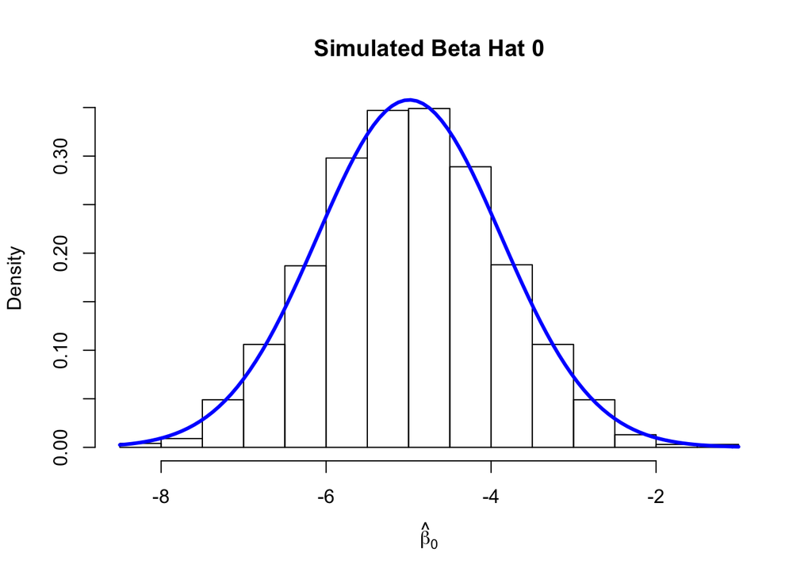

```r
hist( beta.hat.iter[ , "beta.hat.0"],
      prob = TRUE, breaks = 20,
      xlab = expression( hat(beta)[0] ),
      main = "Simulated Beta Hat 0" )

curve( dnorm( x, mean = beta.0.mean, sd = beta.0.sd ),
       col = 'blue', add = TRUE, lwd = 3 )
```

- A histogram of your simulated values for $\hat{\beta}_1$. Add the normal curve for the true sampling distribution of $\hat{\beta}_1$.

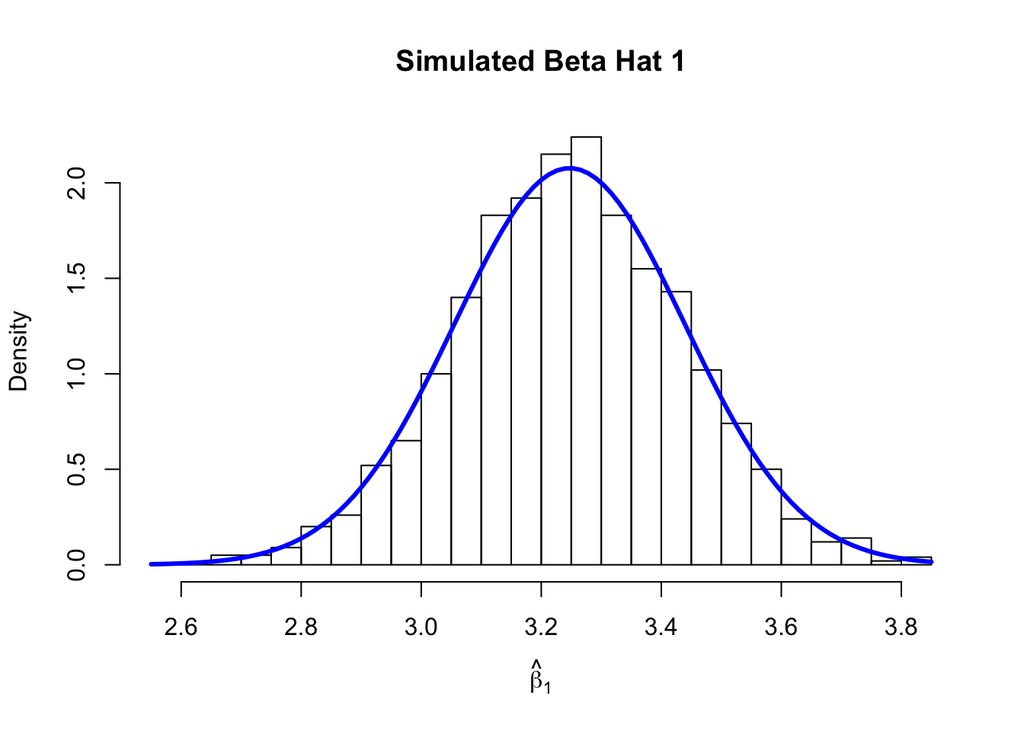

```r
hist( beta.hat.iter[ , "beta.hat.1"],
      prob = TRUE, breaks = 20,
      xlab = expression( hat(beta)[1] ),
      main = "Simulated Beta Hat 1" )

curve( dnorm( x, mean = beta.1.mean, sd = beta.1.sd ),
       col = 'blue', add = TRUE, lwd = 3 )
```

# Exercise 4 (Simulating Confidence Intervals)

### A

Simulate this model $2500$ times. Each time use `lm()` to fit a simple linear regression model, then store the value of $\hat{\beta}_1$ and $s_e$.

```r
set.seed(19920917)

beta.0    <- 5
beta.1    <- 2
sigma.sqr <- 9
sigma     <- 3
n         <- 25
x         <- seq(0, 2.5, length = n)

sim.slr <- function( x, beta.0, beta.1, sigma )
{
    n       <- length(x)
    epsilon <- rnorm( n, mean = 0, sd = sigma )
    y       <- beta.0 + ( beta.1 * x ) + epsilon
    data.frame( predictor = x, response = y )
}

result.table           <- matrix( 0, 5000, nrow = 2500, ncol = 2 )
colnames(result.table) <- c( "beta.hat.1", "se" )

for ( i in 1:2500 )
{
    slr.iter.model     <- sim.slr( x, beta.0, beta.1, sigma )
    lm.iter            <- lm( slr.iter.model$response ~ slr.iter.model$predictor, data = slr.iter.model )
    result.table[i, 1] <- coef(lm.iter)[2]
    result.table[i, 2] <- summary(lm.iter)$coefficients[ 2, 2 ]
}
```

### B

For each of the $\hat{\beta}_1$ that you simulated, calculate a 95% confidence interval. Store the lower limits in a vector `lower_95` and the upper limits in a vector `upper_95`.

```r
alpha <- ( 1 - .95 ) / 2
crit  <- qt( 1 - alpha, df = n - 1 )
me    <- crit * result.table[ , 2]

lower_95 <- result.table[ , 1] - me
upper_95 <- result.table[ , 1] + me
```

### C

What proportion of these intervals contains the true value of $\beta_1$?

```r
sum <- 0

for ( i in 1:length(lower_95) )
{
    if ( lower_95[i] <= beta.1 && beta.1 <= upper_95[i] ) { sum <- sum + 1 }
}

prop <- sum / length(lower_95)
prop
```

```
## [1] 0.9512
```

### D

Based on these intervals, what proportion of the simulations would reject the test $H_0: \beta_1 = 0$ vs $H_1: \beta_1 \neq 0$ at $\alpha = 0.05$?

```r
t.stat   <- ( result.table[ , 1] - beta.1 ) / result.table[ , 2]
p.values <- pt( t.stat, n - 1 )

sum <- 0

for ( i in 1:length(p.values) )
{
    if ( p.values[i] < .05 ) { sum <- sum + 1 }
}

prop <- sum / length(lower_95)
prop
```

```
## [1] 0.0508
```

### E

For each of the $\hat{\beta}_1$ that you simulated, calculate a 99% confidence interval. Store the lower limits in a vector `lower_99` and the upper limits in a vector `upper_99`.

```r
alpha <- ( 1 - .99 ) / 2
crit  <- qt( 1 - alpha, df = n - 1 )
me    <- crit * result.table[ , 2]

lower_99 <- result.table[ , 1] - me
upper_99 <- result.table[ , 1] + me
```

### F

What proportion of these intervals contains the true value of $\beta_1$?

```r
sum <- 0

for ( i in 1:length(lower_99) )
{
    if ( lower_99[i] <= beta.1 && beta.1 <= upper_99[i] ) { sum <- sum + 1 }
}

prop <- sum / length(lower_99)
prop
```

```
## [1] 0.99
```

### G

Based on these intervals, what proportion of the simulations would reject the test $H_0: \beta_1 = 0$ vs $H_1: \beta_1 \neq 0$ at $\alpha = 0.01$?

```r
t.stat   <- ( result.table[ , 1] - beta.1 ) / result.table[ , 2]
p.values <- pt( t.stat, n - 1 )

sum <- 0

for ( i in 1:length(p.values) )
{
    if ( p.values[i] < .01 ) { sum <- sum + 1 }
}

prop <- sum / length(lower_99)
prop
```

```
## [1] 0.0128
```

# Exercise 5 (Prediction Intervals “without” `predict`)

### A

Write a function named `calc_pred_int` that performs calculates prediction intervals:

$$\hat{y}(x) \pm t_{\alpha/2, n - 2} \cdot s_e\sqrt{1 + \frac{1}{n}+\frac{(x-\bar{x})^2}{S_{xx}}}.$$

```r
calc_pred_int <- function( model, newdata, level = .95 )
{
    beta.0.hat <- coef(model)[1]
    beta.1.hat <- coef(model)[2]
    y.hat      <- beta.0.hat + ( beta.1.hat * newdata$Bwt )

    se    <- summary(model)$sigma
    alpha <- ( 1 - level ) / 2
    crit  <- qt( 1 - alpha, df = model$df.residual )

    return ( c( "fit" = y.hat,
                "lwr" = y.hat - crit * se,
                "upr" = y.hat + crit * se ) )
}
```

### B

After writing the function, run this code:

```r
newcat_1 = data.frame(Bwt = 4.0)
calc_pred_int(cat.model, newcat_1)
```

```
## fit.(Intercept) lwr.(Intercept) upr.(Intercept)
##        15.77959        12.90852        18.65066
```

### C

After writing the function, run this code:

```r
newcat_2 = data.frame(Bwt = 3.3)
calc_pred_int(cat.model, newcat_2, level = 0.99)
```

```
## fit.(Intercept) lwr.(Intercept) upr.(Intercept)
##        12.95574         9.16375        16.74774
```